# P4: Explore and Summarize Financial Contributions to 2012 Presidential Campaigns by Igor Buinyi

### Data preprocessing and description

For this project, I chose the data on contributions to 2012 Presidential campaigns funds. I am somehow involved into a political life in Ukraine, which is trying to develop democratic institutions in general and transparent political parties in particular. I would like to expand my knowledge of the international best practices in political financing, so the topic is of interest to me. I am happy to learn something about the topic during this project.

In particular, I chose **Missouri (MO)** state for the analysis because I wonder about the difference between how much rural and urban areas contribute to the campaign financing. I think Missouri with its 70%/30% urban/rural population is a good choice (*Source: Table 3 in Missouri: 2010. Population and Housing Unit Counts. http://www.census.gov/prod/cen2010/cph-2-27.pdf*).

The csv file contains comma at the end of the line, so I needed to add a comma at the end of the header to avoid the error in loading data (*http://stackoverflow.com/questions/8854046/duplicate-row-names-are-not-allowed-error-in-r-programming*).

The summary is presented below. After reviewing the summary, I decided to:

1. exclude *‘cmte_id’* and *‘cand_id’* variables because they containe the same information as candidate name variable *‘cand_nm’*.
2. exclude *‘contbr_st’* variable which is simply state code ‘MO’

I also transformed *‘receipt_desc’* and *‘memo_text’* to strings.

```r
summary(data)
```

```
##       cmte_id           cand_id                cand_nm
##  C00431445:48865   P80003338:48865   Obama, Barack :48865
##  C00431171:24220   P80003353:24220   Romney, Mitt  :24220
##  C00495820: 2535   P80000748: 2535   Paul, Ron     : 2535
##  C00496034: 1081   P20002721: 1081   Santorum, Rick: 1081
##  C00496497:  910   P60003654:  910   Gingrich, Newt:  910
##  C00496067:  349   P00003608:  349   Cain, Herman  :  349
##  (Other)  :  544   (Other)  :  544   (Other)       :  544
##               contbr_nm           contbr_city    contbr_st
##  FUCHS, MICHAEL    :  136   SAINT LOUIS :14598   MO:78504
##  BEHLMANN, MATTHEW :  117   KANSAS CITY : 8914
##  HALL, DUANE R. MR.:  105   ST. LOUIS   : 3862
##  ROGERS, MICHAEL   :  100   COLUMBIA    : 3754
##  WYN, MARK         :   94   SPRINGFIELD : 3054
##  LAWFIELD, JOYCE   :   86   CHESTERFIELD: 2341
##  (Other)           :77866   (Other)     :41981
##    contbr_zip                                     contbr_employer
##  Min.   :1.40e+03   RETIRED                               :17521
##  1st Qu.:6.52e+04   SELF-EMPLOYED                         : 7247
##  Median :6.31e+08   NOT EMPLOYED                          : 4317
##  Mean   :4.58e+08   INFORMATION REQUESTED PER BEST EFFORTS: 2960
##  3rd Qu.:6.41e+08   INFORMATION REQUESTED                 : 1942
##  Max.   :6.59e+08   (Other)                               :44454
##  NA's   :1          NA's                                  :   63
##                               contbr_occupation contb_receipt_amt
##  RETIRED                               :19743   Min.   :-5000
##  INFORMATION REQUESTED PER BEST EFFORTS: 2830   1st Qu.:   25
##  PHYSICIAN                             : 2543   Median :   50
##  ATTORNEY                              : 2455   Mean   :  220
##  HOMEMAKER                             : 2436   3rd Qu.:  150
##  (Other)                               :48487   Max.   : 8000
##  NA's                                  :   10
##  contb_receipt_dt                         receipt_desc   memo_cd
##  Min.   :2011-03-04                             :77699    :58502
##  1st Qu.:2012-06-28   Refund                    :  456   X:20002
##  Median :2012-09-13   REDESIGNATION FROM PRIMARY:   66
##  Mean   :2012-07-29   REDESIGNATION TO GENERAL  :   66
##  3rd Qu.:2012-10-16   REATTRIBUTION TO SPOUSE   :   46
##  Max.   :2012-12-31   REATTRIBUTION FROM SPOUSE :   45
##                       (Other)                   :  126
##                                memo_text      form_tp
##                                     :58266   SA17A:58330
##  TRANSFER FROM ROMNEY VICTORY INC.  :10154   SA18 :19718
##  * OBAMA VICTORY FUND 2012          : 9502   SB28A:  456
##  * EARMARKED CONTRIBUTION: SEE BELOW:   75
##  REDESIGNATION FROM PRIMARY         :   66
##  REDESIGNATION TO GENERAL           :   66
##  (Other)                            :  375
##     file_num              tran_id       election_tp
##  Min.   :723511   SA17.447586 :    4   G2012  :44230
##  1st Qu.:810684   SA17.835442 :    3   P2012  :34236
##  Median :821325   SA17.1000028:    2   O2012  :   24
##  Mean   :833724   SA17.1000468:    2          :    4
##  3rd Qu.:842943   SA17.1000510:    2   P2008  :    4
##  Max.   :992728   SA17.1000611:    2   P      :    3
##                   (Other)     :78489   (Other):    3
```

```r
data<-data[,names(data)!=c('cmte_id','cand_id','contbr_st')]
data$receipt_desc<-as.character(data$receipt_desc)
data$memo_text<-as.character(data$memo_text)
str(data)
```

```
## 'data.frame':    78504 obs. of  15 variables:
##  $ cand_nm          : Factor w/ 13 levels "Bachmann, Michele",..: 7 7 6 6 7 7 7 6 6 6 ...
##  $ contbr_nm        : Factor w/ 18434 levels "A JONES, JANE",..: 7712 5009 1270 17580 7601 7877 13548 3329 15987 2232 ...
##  $ contbr_city      : Factor w/ 814 levels "ADRIAN","ADVANCE",..: 409 409 628 233 628 628 628 641 513 249 ...
##  $ contbr_zip       : int  640689345 640682096 63146 63034 631432506 631052517 631293954 63780 633662418 631313416 ...
##  $ contbr_employer  : Factor w/ 7258 levels "","\\","1 MARK TWAIN MUSEUM/2 QUINCY UNIVERS",..: 5216 1200 5426 5888 6230 2843 1498 5073 5073 5073 ...
##  $ contbr_occupation: Factor w/ 3989 levels "","\\NONE\\",..: 2702 612 2576 374 1196 2474 903 3089 3089 277 ...
##  $ contb_receipt_amt: num  100 201 100 100 100 ...
##  $ contb_receipt_dt : Date, format: "2011-12-06" "2011-12-06" ...
##  $ receipt_desc     : chr  "" "" "" "" ...
##  $ memo_cd          : Factor w/ 2 levels "","X": 1 1 1 1 1 1 1 1 1 1 ...
##  $ memo_text        : chr  "" "" "" "" ...
##  $ form_tp          : Factor w/ 3 levels "SA17A","SA18",..: 1 1 1 1 1 1 1 1 1 1 ...
##  $ file_num         : int  779227 779227 756218 756218 779227 779227 779227 756218 756218 756218 ...
##  $ tran_id          : Factor w/ 67887 levels "0000009","0000023",..: 1703 1704 4237 4544 1713 1714 1715 3965 4612 4341 ...
##  $ election_tp      : Factor w/ 8 levels "","G2008","G2012",..: 7 7 7 7 7 7 7 7 7 7 ...
```

While doing the later analysis I discovered that:

1. The dataset includes 208 transactions with zip codes outside MO. They are likely produced by input errors since many of such transactions are with zip codes from MD and MN states. (I checked that the corresponding city names from *‘contbr_city’* point to cities outside MO as well). **I decided to exclude those 208 transactions.**
2. City names in *‘contbr_city’* need much cleaning. For example, *ST LOIUS*, *SAINT LOUIW* and *SAINT LUOIS* should be replace with *SAINT LOUIS*. In total, I replaced 138 different city names in 7369 transactions (or about 10% of the dataset size).

Also, I tried to recover city names from zip codes, but it is impossible to easily match zip code level data with population data from census, which I will do later. So, I used city names from cleaned *‘contbr_city’* variable and did not recover city names from zip codes.

I will use the 2010 census population data from *http://www.togetherweteach.com/TWTIC/uscityinfo/25mo/mopopr/25mopr.htm* to assess how contributions differ for urban and rural areas.

```
##
##    10    13    20    21    22    28    30    33    37    39    48    50
##     3    86     3    12     5    10     1     2     4     4     1     7
##    53    56    59    60    63    64    65    68    73    83
##    11    24    15     8 41751 20830 15715     3     2     6
```

```
## [1] "Drop 208 trancastions with incorrect zip code"
```

```
## [1] "Drop  451 transactions after the Election Date (Nov 6, 2012)"
```

```
## [1] "Drop  61 transactions with zero amount"
```

```
##      contbr_city population
## 1    KANSAS CITY     459787
## 2    SAINT LOUIS     319294
## 3    SPRINGFIELD     159498
## 4   INDEPENDENCE     116830
## 5       COLUMBIA     108500
## 6    LEES SUMMIT      91364
## 7       O FALLON      79329
## 8   SAINT JOSEPH      76780
## 9  SAINT CHARLES      65794
## 10  BLUE SPRINGS      52575
```

```
## [1] "7369 city names corrected"
```

```
## [1] "6637 employer names corrected"
```

```
## [1] "There are 77784 transactions in the dataset"
```

```
## [1] "18364 unique donators"
```

## Univariate Plots Section

### By transaction amount

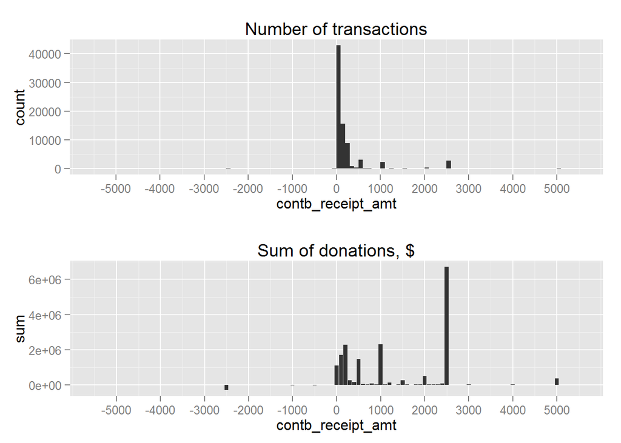

```
## [1] "The total sum of contributions: 17239097.55 USD"
```

```
## [1] "Number of positive amount transactions: 77284"
```

```
## [1] "Sum of positive amount transactions: 17674932.37USD"
```

```
## [1] "Number of negative amount transactions: 500"
```

```
## [1] "Sum of negative amount transactions: -435834.82USD"
```

```
## [1] "Positive amount receipts"
```

```
##    Min. 1st Qu.  Median    Mean 3rd Qu.    Max.
##       1      25      50     229     150    8000
```

```
## [1] 1.8e+07
```

```
## [1] "Negative amount receipts"
```

```
##    Min. 1st Qu.  Median    Mean 3rd Qu.    Max.
##   -5000   -2000    -250    -872     -50      -1
```

```
## [1] -435835
```

The major part of transactions are between $1 and $500 Some of the transactions are with negative amount. The sum of negative transactions is about 3% of the total contributions. Let’s study a bit more why the negative transactions occur. The information can be accessed in *‘receipt_desc’* variable. If it is empty, I will use the description from *‘memo_text’* variable.

```
##                                               reason   n donators     sum
## 1                                             Refund 298      179 -133910
## 2                           REDESIGNATION TO GENERAL  66       39 -110659
## 3                            REATTRIBUTION TO SPOUSE  43       32  -59990
## 4                  TRANSFER FROM ROMNEY VICTORY INC.  53       26  -74976
## 5                          * OBAMA VICTORY FUND 2012   9        8   -3825
## 6                      REDESIGNATION TO PRIMARY DEBT  14        7  -28000
## 7                                                      5        4   -3725
## 8                                       CHARGED BACK   3        3   -2825
## 9                             CHECK RETURNED BY BANK   2        2   -5025
## 10 EARMARK:  ACT RIGHT PAC; REDESIGNATION TO GENERAL   4        2  -10000
## 11                                                 *   1        1    -150
## 12                          REDESIGNATION TO PRIMARY   1        1   -2500
## 13                                      STOP PAYMENT   1        1    -250
##     mean median sum_per_donator n_per_donator
## 1   -449   -100            -748           1.7
## 2  -1677  -2500           -2837           1.7
## 3  -1395  -1500           -1875           1.3
## 4  -1415  -1265           -2884           2.0
## 5   -425   -250            -478           1.1
## 6  -2000  -2500           -4000           2.0
## 7   -745   -100            -931           1.2
## 8   -942   -300            -942           1.0
## 9  -2512  -2512           -2512           1.0
## 10 -2500  -2500           -5000           2.0
## 11  -150   -150            -150           1.0
## 12 -2500  -2500           -2500           1.0
## 13  -250   -250            -250           1.0
```

So, the major reasons for negative transactions are *“Refund”* and *“REDESIGNATION TO GENERAL”*. They are obviously netted with the corresponding positive amount transactions, so we can easily calculate the correct sum of donations by simply adding all, positive and negative, transactions.

However, to analyze transaction-level data, it would be a wise idea to clear both positive and negative transactions. Unfortunately, this cannot be done in a straightforward way at transaction level because it is not possible to identify the original positive transaction for each negative transaction. The example is given below:

```
##             cand_nm       contbr_nm contb_receipt_amt contb_receipt_dt
## 5889  Obama, Barack DUNLAP, JEAN E.                50       2012-06-19
## 7951  Obama, Barack DUNLAP, JEAN E.              -870       2012-06-23
## 8843  Obama, Barack DUNLAP, JEAN E.               100       2012-08-17
## 15179 Obama, Barack DUNLAP, JEAN E.               250       2012-10-11
## 18625 Obama, Barack DUNLAP, JEAN E.                50       2012-10-19
## 18626 Obama, Barack DUNLAP, JEAN E.                50       2012-11-03
## 36535 Obama, Barack DUNLAP, JEAN E.                50       2012-08-19
## 37027 Obama, Barack DUNLAP, JEAN E.              1000       2012-08-31
## 59253 Obama, Barack DUNLAP, JEAN E.                50       2012-07-19
## 62854 Obama, Barack DUNLAP, JEAN E.               100       2012-08-17
## 64142 Obama, Barack DUNLAP, JEAN E.                50       2012-09-19
##       receipt_desc memo_text   tran_id election_tp
## 5889                         C17007556       G2012
## 7951        Refund              D43806       G2012
## 8843                         C21932393       G2012
## 15179                        C25610051       G2012
## 18625                        C26741131       G2012
## 18626                        C29611643       G2012
## 36535                        C19522732       G2012
## 37027                        C20401905       G2012
## 59253                        C18215273       G2012
## 62854                        C19472559       G2012
## 64142                        C22416451       G2012
```

```
##             cand_nm      contbr_nm contb_receipt_amt contb_receipt_dt
## 16902 Obama, Barack BRADY, GEORGIA               -90       2012-10-12
## 20216 Obama, Barack BRADY, GEORGIA                10       2012-10-31
## 39525 Obama, Barack BRADY, GEORGIA                10       2012-09-21
## 40974 Obama, Barack BRADY, GEORGIA                10       2012-09-09
## 48257 Obama, Barack BRADY, GEORGIA                15       2012-10-25
## 64728 Obama, Barack BRADY, GEORGIA               100       2012-09-29
## 69219 Obama, Barack BRADY, GEORGIA                10       2012-10-17
##       receipt_desc                 memo_text   tran_id election_tp
## 16902       Refund                              D69953       G2012
## 20216                                        C28750076       G2012
## 39525                                        C22711875       G2012
## 40974              * OBAMA VICTORY FUND 2012 C25149456       G2012
## 48257              * OBAMA VICTORY FUND 2012 C29109381       G2012
## 64728                                        C23456434       G2012
## 69219                                        C26560045       G2012
```

Mr. JEAN E. DUNLAP refunded $870 on 2012-06-23, but it is impossible to identify when he donated the money before the refund date. We can see a donation of only $50 on 2012-06-19. Similarly, Mrs. GEORGIA BRADY refunded $90 on 2012-10-12, which cannot be a compound of some of her prior donations.

That is why it is not possible to match the original positive transactions to negative transactions. Therefore, **for some part of the analysis I will ignore all transactions of nonpositive value**. Specifically, when analysing contributions by time of transactions I will ignore nonpositive transactions, unless otherwise noted. I believe, that such an approach is capable of capturing the major facts hidden in the data and will not lead to errors in our conclusions.

### By time of transaction

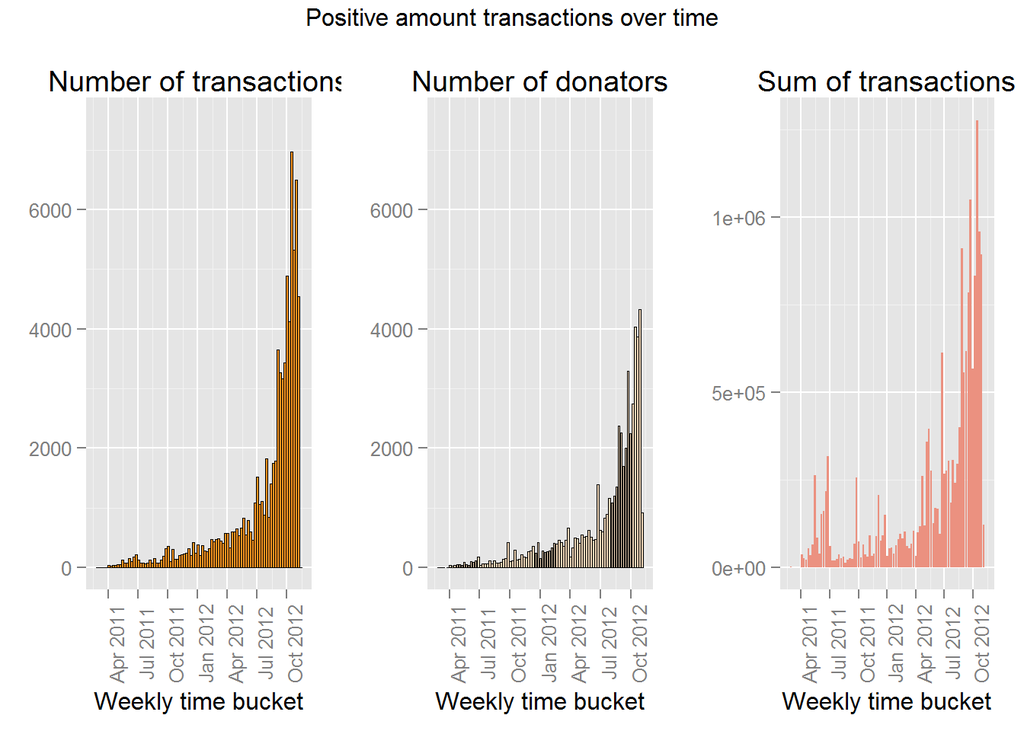

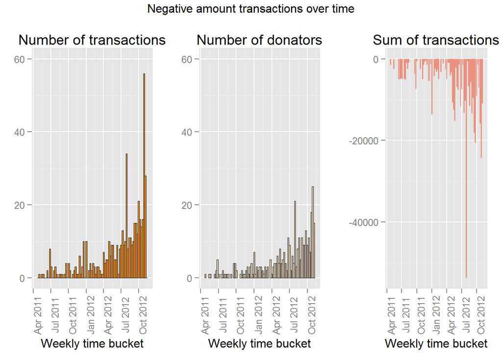

In September-October 2012 the contributions to reach the maximum level ~4000 donators per week and ~$1M per week.

### By contributor

```
## [1] "18364 unique donators in the dataset"
```

```
##  sum_per_donator
##  Min.   :-6000
##  1st Qu.:  155
##  Median :  350
##  Mean   :  939
##  3rd Qu.:  890
##  Max.   :20000
```

### By candidate

Missouri held Republican primaries in 2012, so there are a number of Republican candidates in the dataset. In datasets for the majority of the other states, the number of unique candidates will be much smaller.

In our dataset, **Barack Obama** represents Democratic Party, **Gary Earl Johnson** - Libertarian Party, **Jill Stein** - Green Party, and the others are from Republican Party. I also created a new variable *party* to study Republican candidates as one group when I need to do so.

```
##                           cand_nm     n donators     sum mean median
## 1                   Obama, Barack 48354     9987 4.7e+06   98     40
## 2                    Romney, Mitt 24013     6474 1.1e+07  477    125
## 3                       Paul, Ron  2535      760 3.2e+05  127    100
## 4                  Santorum, Rick  1081      488 2.1e+05  198    100
## 5                  Gingrich, Newt   910      379 2.0e+05  217    100
## 6                    Cain, Herman   349      214 1.1e+05  302    250
## 7               Bachmann, Michele   243      115 5.2e+04  215    100
## 8  Roemer, Charles E. 'Buddy' III    94       91 5.0e+03   53     25
## 9                     Perry, Rick    52       47 6.8e+04 1313   1000
## 10              Pawlenty, Timothy    40       35 4.4e+04 1090   1000
## 11             Johnson, Gary Earl    74       26 2.9e+04  394    250
## 12                  Huntsman, Jon    32       10 7.5e+03  236     50
## 13                    Stein, Jill     7        6 1.2e+03  179    150
##    sum_per_donator n_per_donator
## 1              475           4.8
## 2             1768           3.7
## 3              425           3.3
## 4              438           2.2
## 5              522           2.4
## 6              492           1.6
## 7              455           2.1
## 8               54           1.0
## 9             1453           1.1
## 10            1246           1.1
## 11            1121           2.8
## 12             754           3.2
## 13             208           1.2
```

```
##         party     n donators     sum mean median sum_per_donator
## 1  Democratic 48354     9987 4.7e+06   98     40             475
## 2  Republican 29349     8391 1.2e+07  425    100            1485
## 3 Libertarian    74       26 2.9e+04  394    250            1121
## 4       Green     7        6 1.2e+03  179    150             208
##   n_per_donator
## 1           4.8
## 2           3.5
## 3           2.8
## 4           1.2
```

The average amount per one donator is $475 for Obama and $1768 for Romney. It appears that Obama and Romney pursued very different fundraising strategies.

### By City

```
## [1] "There are 676 cities in the dataset"
```

```
## [1] "There are 950 cities in Missouri"
```

```
##      contbr_city population     n donators     sum mean median
## 1    KANSAS CITY     459787  8902     2148 1862402  209     50
## 2    SAINT LOUIS     319294 19773     5030 5813068  294     56
## 3    SPRINGFIELD     159498  3055      781 1051758  344    100
## 4   INDEPENDENCE     116830   858      199  113517  132     50
## 5       COLUMBIA     108500  3709      808  535533  144     50
## 6    LEES SUMMIT      91364  1723      368  210944  122     50
## 7       O FALLON      79329   739      142   80517  109     40
## 8   SAINT JOSEPH      76780   589      158  122029  207    100
## 9  SAINT CHARLES      65794  1460      353  249031  171     50
## 10  BLUE SPRINGS      52575   584      112   47604   82     50
##    sum_per_donator n_per_donator
## 1              867           4.1
## 2             1156           3.9
## 3             1347           3.9
## 4              570           4.3
## 5              663           4.6
## 6              573           4.7
## 7              567           5.2
## 8              772           3.7
## 9              705           4.1
## 10             425           5.2
```

```
## [1] "Top20 cities (by population): 49% of population"
```

```
## [1] "66% of all contributors"
```

```
## [1] "and 70% of total sum contributed"
```

To cover all cities in the dataset, I make a few groups by city population. Kansas City and Saint Louis will be in separate groups, Springfield, Independence and Columbia are bundled together in group *100k-300k* and so on. I did not match 115 cities in the dataset to population data, but they correspond only to 2% of donators and total sum of contributions in the dataset.

```
## Source: local data frame [10 x 5]
##
##          pop_grp ncities totalpopulation donators     sum
## 1      (0,1e+03]     608          195539      744  590169
## 2  (1e+03,5e+03]     213          502818     1418 1013820
## 3  (5e+03,1e+04]      52          369660      945  939431
## 4  (1e+04,2e+04]      45          624056     2039 1969898
## 5  (2e+04,5e+04]      19          557650     2360 1959086
## 6  (5e+04,1e+05]       8          520725     1709 1100796
## 7  (1e+05,3e+05]       3          384828     1788 1700807
## 8  (3e+05,4e+05]       1          319294     5030 5813068
## 9  (4e+05,5e+05]       1          459787     2148 1862402
## 10            NA     115               0      385  289620
```

### By Employer

```
##              contbr_employer     n donators     sum mean median
## 1                    RETIRED 17559     3856 3043469  173     50
## 2              SELF-EMPLOYED  8068     1974 1642233  204     56
## 3    INFO REQ. PER BEST EFF.  2946     1186 1422309  483    200
## 4      INFORMATION REQUESTED  1883     1136  356770  189    100
## 5               NOT EMPLOYED  4303     1013  425932   99     40
## 6                  HOMEMAKER  1705      528 1044565  613    120
## 7                       NONE  1272      382  282866  222    100
## 8      WASHINGTON UNIVERSITY  1535      329  223649  146     50
## 9  MISSOURI STATE UNIVERSITY  1119      219  113306  101     50
## 10                             352      203  -19355  -55    -99
## 11         STATE OF MISSOURI   406      103   42295  104     50
## 12    SAINT LOUIS UNIVERSITY   329       96   63564  193     50
## 13                       N/A   259       90   38283  148     55
## 14    UNIVERSITY OF MISSOURI   493       87   47541   96     50
```

[output cut: 17 more lines]

```
## [1] "Number of unique employers: 6641"
```

```
## [1] "Top20 employers (by number of transactions): 56% of all contributors"
```

```
## [1] "and 53% of total sum contributed"
```

### By Occupation

```
##          contbr_occupation     n donators     sum mean median
## 1                  RETIRED 19608     4463 3337871  170     50
## 2  INFO REQ. PER BEST EFF.  2802     1121 1323244  472    200
## 3    INFORMATION REQUESTED  1672     1026  331268  198    100
## 4                HOMEMAKER  2416      696 1119728  463    100
## 5                 ATTORNEY  2435      669  761470  313    100
## 6                PHYSICIAN  2516      653  779476  310    100
## 7                PROFESSOR  1525      331  190536  125     50
## 8                PRESIDENT   643      229  546233  850    250
## 9                  TEACHER  1005      221   71043   71     35
## 10                           356      207  -18755  -53    -92
##    sum_per_donator n_per_donator
## 1              748           4.4
## 2             1180           2.5
## 3              323           1.6
## 4             1609           3.5
## 5             1138           3.6
## 6             1194           3.9
## 7              576           4.6
## 8             2385           2.8
## 9              321           4.5
## 10             -91           1.7
```

```
## [1] "Number of unique occupations: 3978"
```

```
## [1] "Top20 occupations (by number of transactions): 55% of all contributors"
```

```
## [1] "and 58% of total sum contributed"
```

### By form type

```
##   form_tp     n donators     sum mean median sum_per_donator n_per_donator
## 1   SA17A 57732    14941 1.0e+07  179     50             693           3.9
## 2    SA18 19552     8495 7.3e+06  374    100             861           2.3
```

### By election type

```
##   election_tp     n donators     sum mean median sum_per_donator
## 1       G2012 43566    12842 8553953  196     50             666
## 2       P2012 33718    11033 9120979  271     60             827
##   n_per_donator
## 1           3.4
## 2           3.1
```

# Univariate Analysis

### What is the structure of your dataset?

There were 78504 transactions in the downloaded dataset. They include information about contributor (name, city, zip code, occupation, employer), transaction characteristics (amount, time) and some information at the receiver side (candidate name, election type, form type, descriptions).

There were Republican primaries in Missouri, so I added a party variable to do some analysis at the party level.

Contributions to election funds intensified before the election date. 60% of the total amount was contributed during the last 4 months before the Election Date.

The median transaction size is only $50, but people typically made 4-5 donations over the campaign period, so the median contribution to the campaign is $350 and mean contribution is close to $1,000.

### What is/are the main feature(s) of interest in your dataset?

The two main feature are to measure the result of fundraising campaign: one is the **amount of receipt** and the other (implicitly present) is the  
**count** of transactions or donators.

The most important determinant feature is **candidate name**.

### What other features in the dataset do you think will help support your investigation into your feature(s) of interest?

Basically, the following analysis is about how the interplay between candidate and the number and amount of contributions is affected by the other variables. I am interested in the fundraising campaign results in different cities, over different occupations and over time.

### Did you create any new variables from existing variables in the dataset?

Yes, I created variable *party* from candidate name. Moreover, I used the data from outside the dataset. I loaded the population of cities in Missouri from *http://www.togetherweteach.com/TWTIC/uscityinfo/25mo/mopopr/25mopr.htm* in order to investigate campaign results in rural vs. urban areas.

### Of the features you investigated, were there any unusual distributions? Did you perform any operations on the data to tidy, adjust, or change the form of the data? If so, why did you do this?

I excluded 208 transactions with zip codes outside Missouri, 451 transactions after the Election Date (Nov 6, 2012), and then 61 transactions of zero amount. The resulting dataset consists of 77784 transactions, including 500 with negative amount (they are refunds or retransfers).

In order to analyze the data by cities I corrected 7369 city names and added city population from the other dataset. In addition, I cleaned employer names and election types.

The reasons for this: 1. For this analysis I am interested in the fundraising campaigns in Missouri, not the other states. 2. Transactions after the election date are not likely to be representative. 3. Transactions of zero amount either are errors or have no value for the analysis.

I would also like to match negative (refunds or retransfers) and positive transactions at transaction level and adjust them. However, this is not possible for this dataset. So, I will use only positive transaction for analysis of contributions over time.

I had to clean city and employer names to avoid bias in my conclusions. Few errors in the campaign type variable are corrected just to make the dataset cleaner.

It should be noted, that I assume the names of contributors to be correct (in other words, different values of *contbr_nm* variable correspond to different persons). This is not likely to be a correct assumption given the high number of errors in some other variables, but anyway we do not have a gold standard data for names in the dataset to correct them.

# Bivariate Plots Section

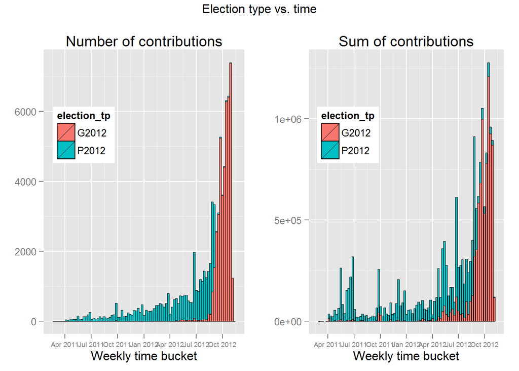

[figure not shown]

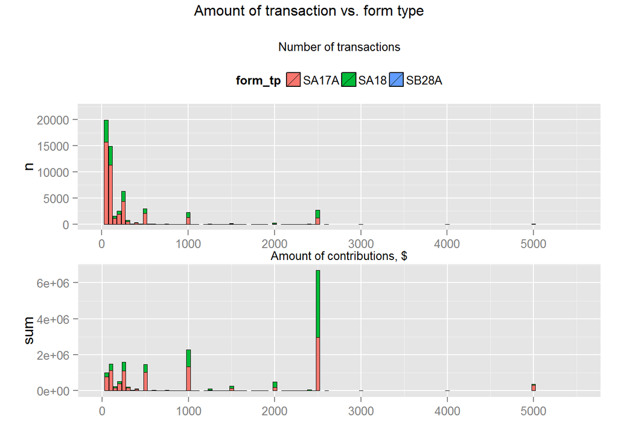

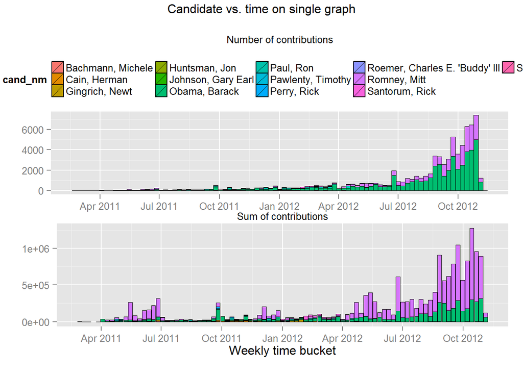

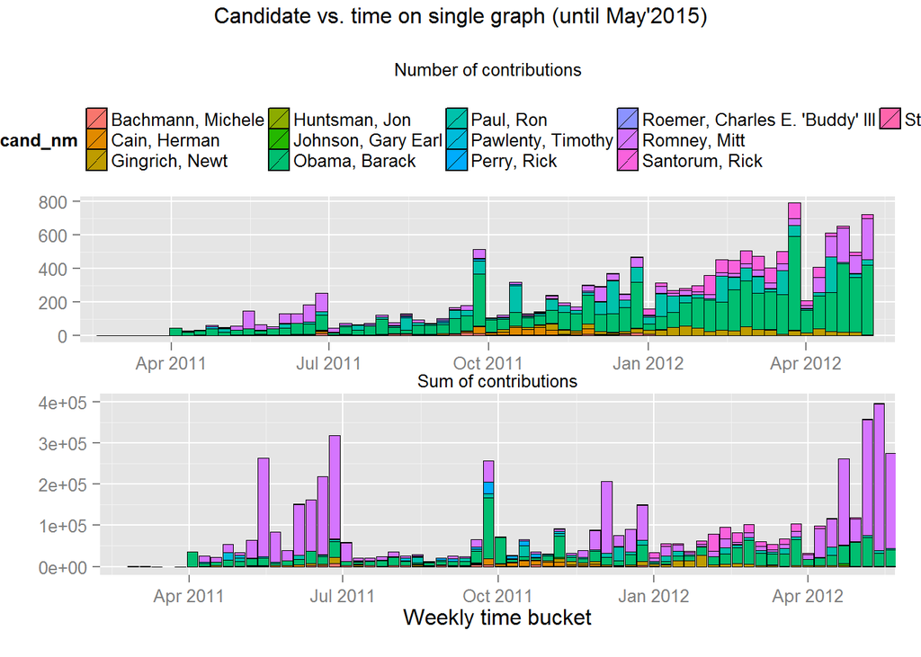

Please see facet wrap plots in the next section (Multivariate plots).

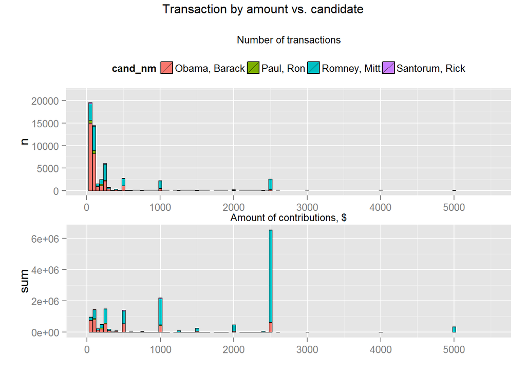

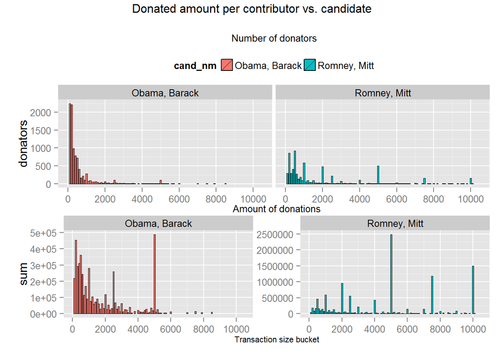

```
## [1] "$4744149.21 donated to Obama's fund"
```

```
## [1] "   including $2952996.42 (or 62%) from those who donated up to $1500"
```

```
## [1] "$11448049.52 donated to Romney's fund"
```

```
## [1] "   including $2342256.4 (or 20%) from those who donated up to $1500"
```

It is clear that Obama received more small transactions, but Romney outperformed him in big transactions. Receipts of $2500 contributed more than $6M to the campaigns, and the major part of these transactions went to Romney’s campaign. Transactions of $5000 almost exclusively went Romney’s campaign, but they were not as popular as $2500 transactions.

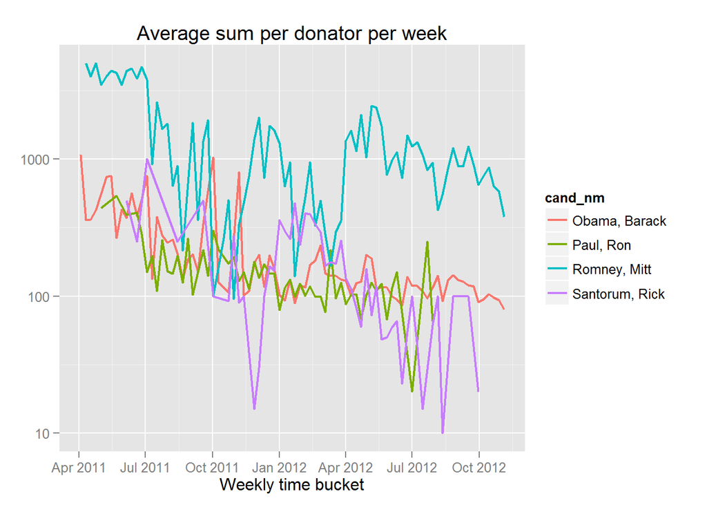

It is remarkable, that the Romney’s campaign stands out from the campaigns of the other Republican candidates. The average weekly donation per contributor is very close for Obama, Paul and Santorum (~$200 in 2011 and ~$100 in 2012), but the number for Romney was up to 10 times higher.

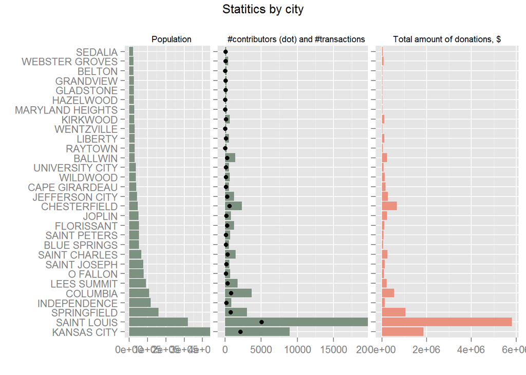

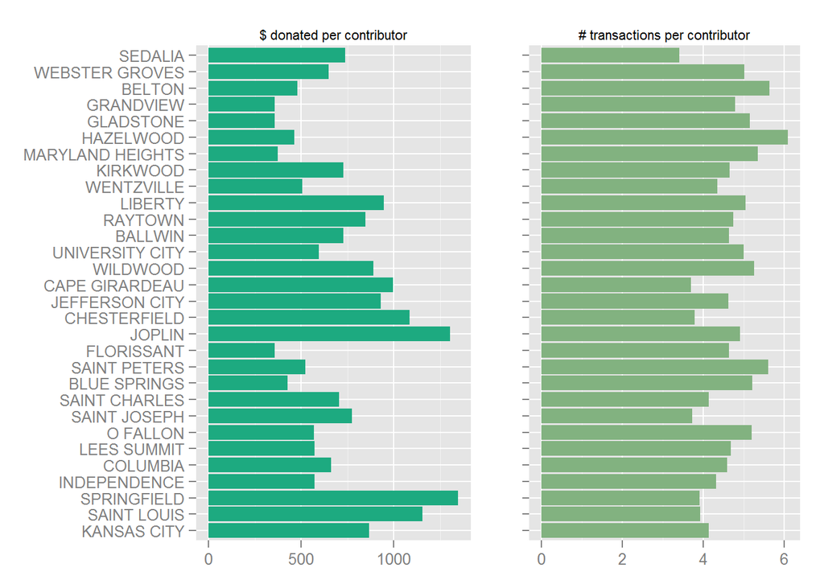

Although the largest city is Kansas City, the contribution from Saint Louis were much more numerous and more valuable. Some cities (Chesterfield, Ballwin) contributed much more than cities with similar population. This can be explained on case-by-case basis by concentration of particular businesses in that city or strong support for a particular politician.

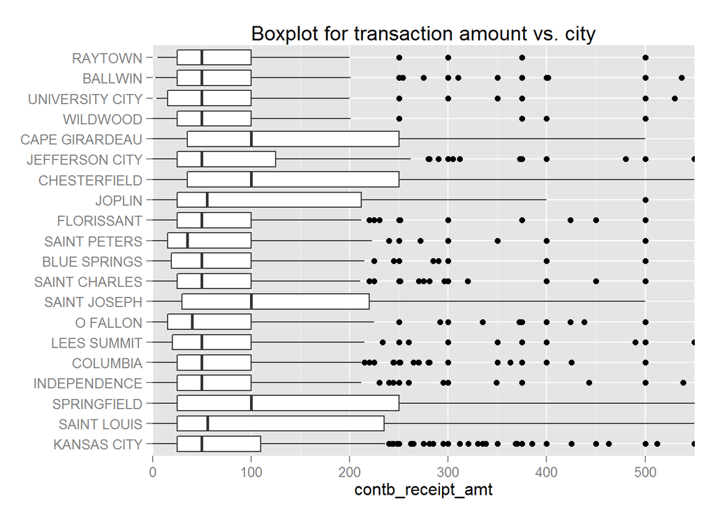

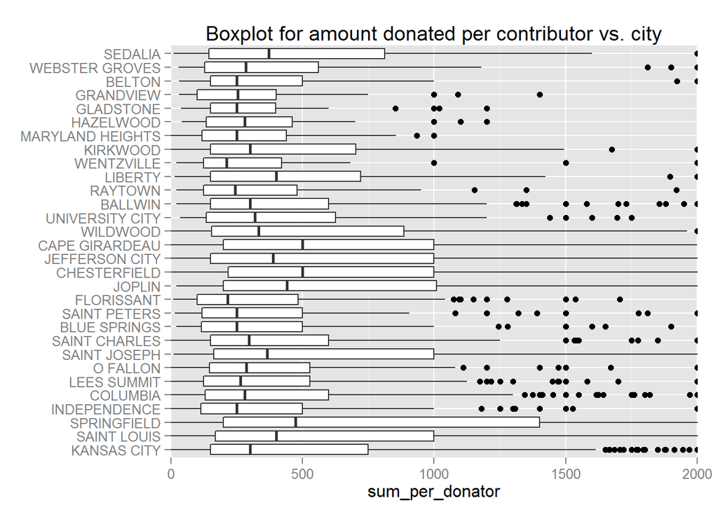

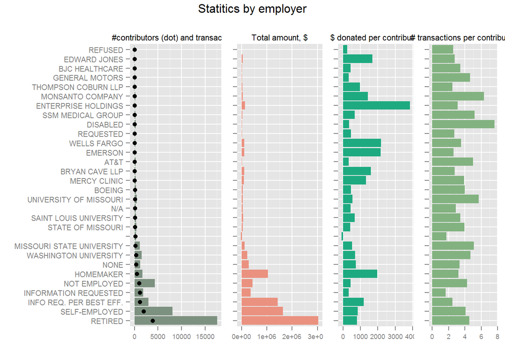

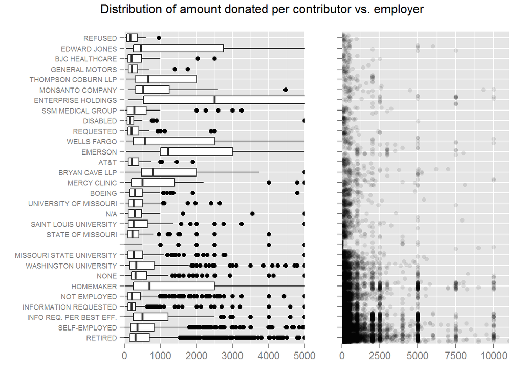

The plot above supports the hypothesis that higher contributions can be due to a concentration of business in particular city. We can see that some employers (*BRYAN CAVE*, *EMERSON*, *Wells Fargo*, *EDWARD JONES*) are characterized by extremely high contributions. Some of them are likely to be localized in a particular city, so they can drive upward the total contributions from that city.

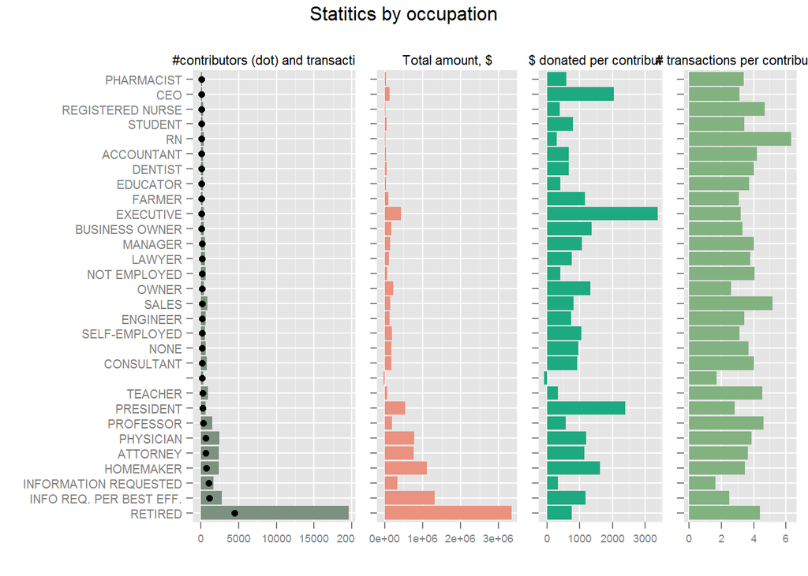

# Bivariate Analysis

### Talk about some of the relationships you observed in this part of the investigation. How did the feature(s) of interest vary with other features in the dataset?

1. Obama got a major part of small receipts, while Romney got most from hefty receipts. The total campaign funds are $4.7M for Obama and $11.4M for Romney. But from those who donated up to $1500 during the campaign, Obama got $2.95M while Romney received only $2.3M
2. Other major Republican candidates (Ron Paul and Rick Santorum), similarly to Democrat Obama, received small contributions to their funds. So, Romney’s fundraising campaign differs not only from Obama’s campaign, but from the campaigns of other Republican candidates.
3. Cities vary by their contributions to the election funds per unit of population. In the next section I will touch this aspect in more detail.
4. Some cities (Chesterfield, Ballwin) contributed much more than cities with similar population. This can be explained on case-by-case basis by concentration of particular businesses in that city or strong support for a particular politician.
5. The effect of occupation on the size of contributions is very evident. Presidents and executives contributed 2-3 times more than the others on average. However, they typically made fewer transactions. They are either have enough money to pay all they want at once, or just put more value on their time than the other people do.

### Did you observe any interesting relationships between the other features (not the main feature(s) of interest)?

6. Contributions to general elections (vs. primary elections) were made mostly over 3 last months before the Election Day.
7. I did not found any strong relationship between form type (“Indicates what schedule and line number the reporting committee reported a specific transaction”, *ftp://ftp.fec.gov/FEC/Presidential_Map/2012/DATA_DICTIONARIES/CONTRIBUTOR_FORMAT.txt*) and other variables. In particular, there is not clear relationship with time or amount of transaction. In the dataset it looks like a quite random variable.

### What was the strongest relationship you found?

The candidate is the major determinant of the contributions. Moreover, it is not the party name (here I talk about Republicans and Democrats only) that determines the result. It is clearly the candidate name that produces consistent results across different dimensions (city, occupation, employer).

# Multivariate Plots Section

```
## [1] "Distribution of the number of receipts by size buckets"
```

```
##
##        (0,50]      (50,100]     (100,200]     (200,500]   (500,1e+03]
##         38834         17009          4573         10891          2539
## (1e+03,2e+03] (2e+03,3e+03] (3e+03,6e+03]
##           599          2756            81
```

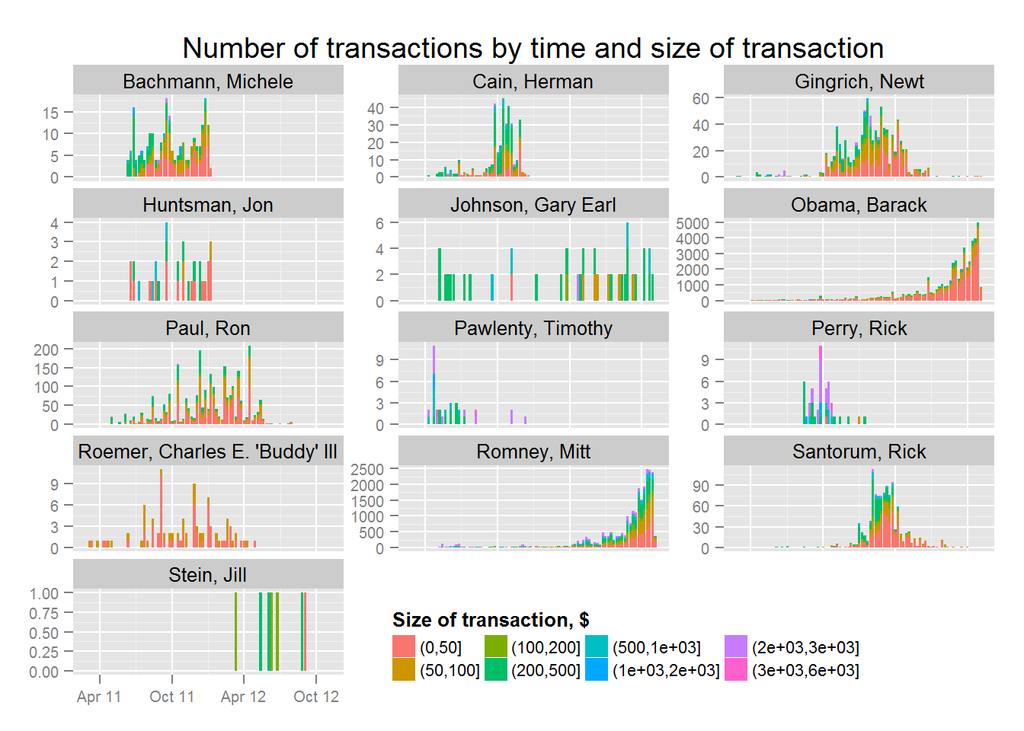

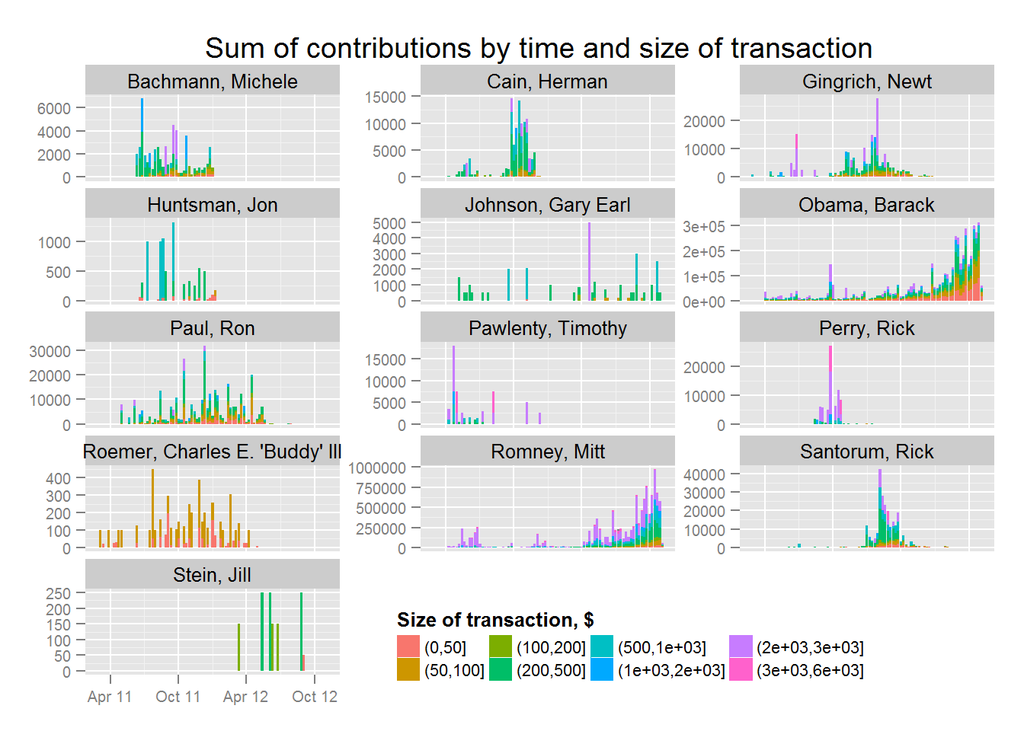

These plots show how each candidate obtained funds to their election campaign. Now I am going to compare Romney and Obama on adjacent plots. I will fill the graphs by amount donated per contributor per week because I find it more important variable then the size of a single transaction.

```
## [1] "Distribution of donated amount over one week by size buckets"
```

```
##
##        (0,50]      (50,100]     (100,200]     (200,500]   (500,1e+03]
##         22336         12537          6193          8472          2023
## (1e+03,2e+03] (2e+03,5e+03] (5e+03,2e+04]
##          1015          1586           218
```

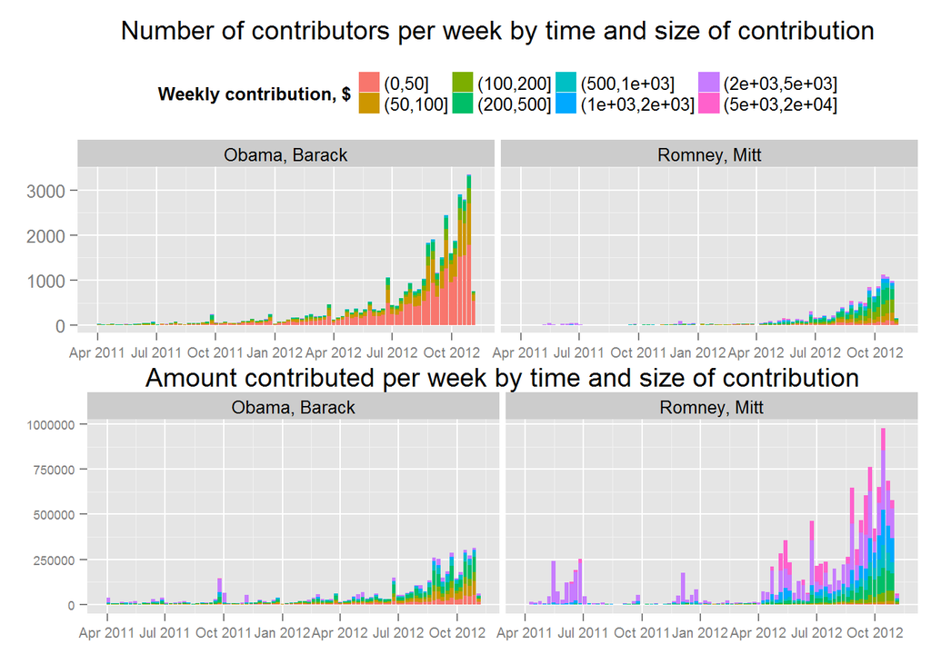

Again, we can see that Obama during the whole campaign period received small donations, while Romney received much larger ones.

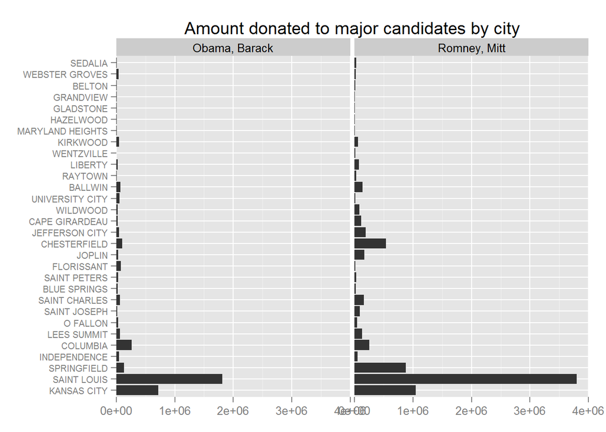

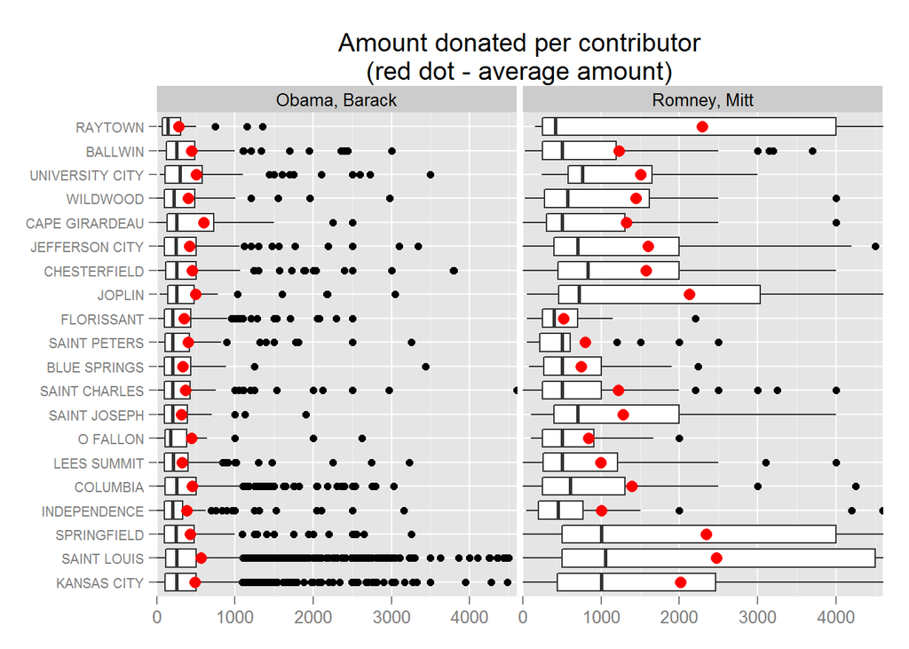

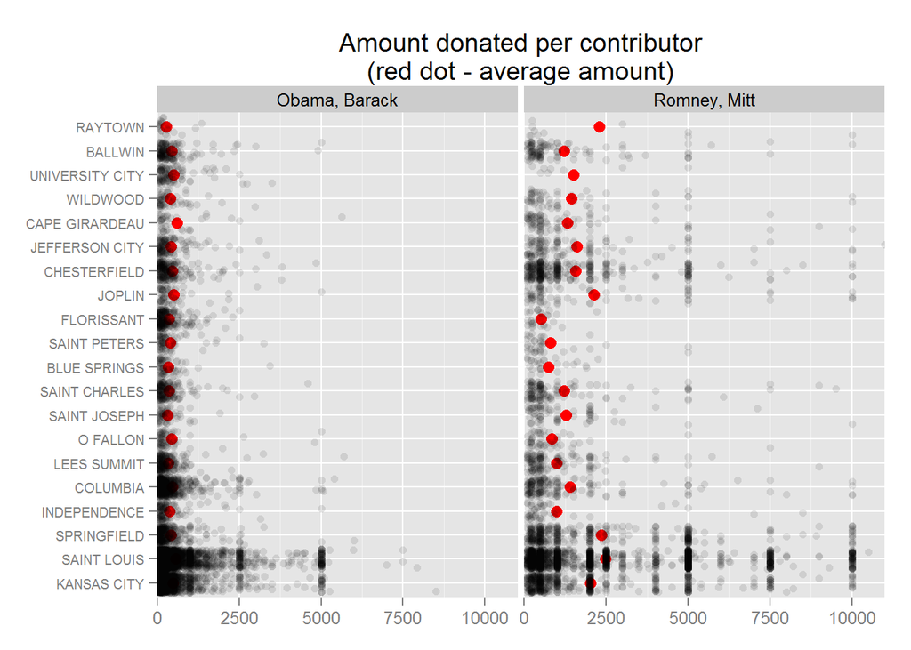

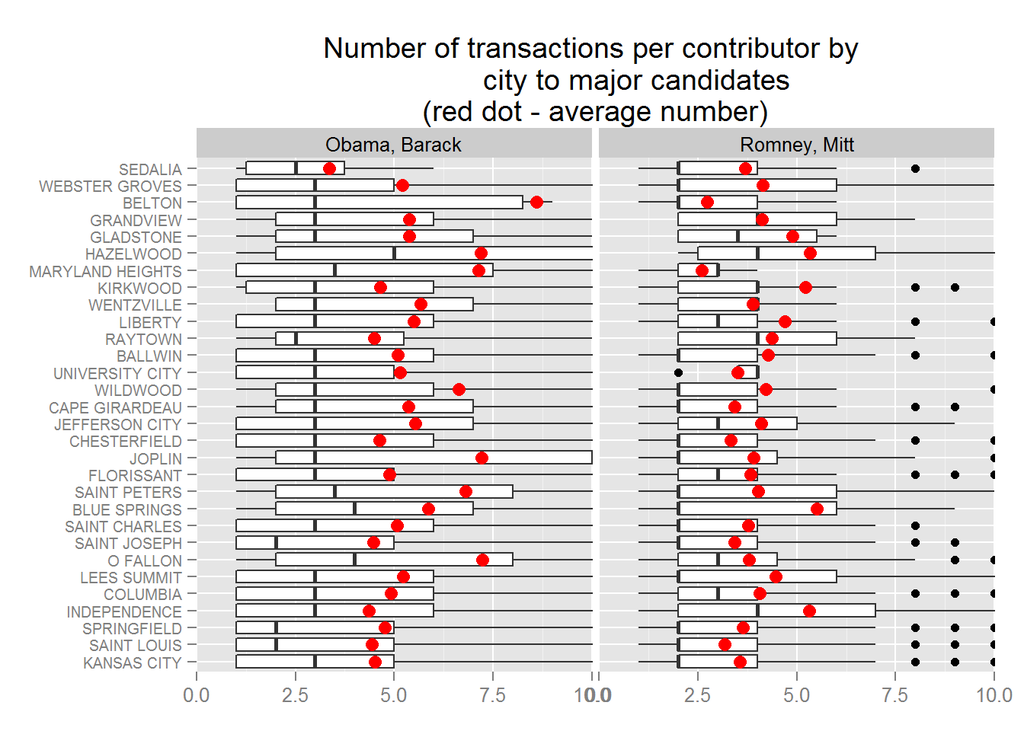

Here we have a closer look at the difference between performance of fundraising campaign for Obama and Romney in top cities by population. It is now clear that high amount of contributions in Joplin, Chesterfield, Jefferson City and some other cities (if compared with cities with similar population) is due to much high donations to Romney’s fund.

Interestingly, Romney managed to get high-amount donations across all the major cities, not just in a few of them. Similarly, donations (per person) to Obama’s fund were small across all the major cities.

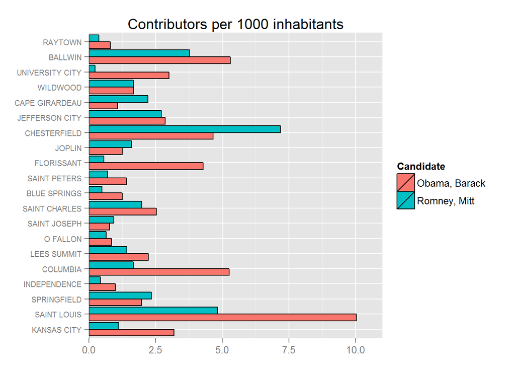

```
## [1] "Contributors per 1000 people: all cities"
```

```
## [1] "Obama:  2.72    Romney:  1.76"
```

```
## [1] "Contributors per 1000 people: all cities except Kansas City and Saint Louis"
```

```
## [1] "Obama:  1.84    Romney:  1.52"
```

Earlier we saw that Obama’s fund received donations from more people. Now it turns out that such a high performance is mostly due to better results in the two largest cities: Kansas City and Saint Louis. If we exclude these two cities, the number of contributors per 1000 people is nearly the same for the two top candidates: 1.84 for Obama and 1.52 for Romney. It should be noted here, that Kansas City and Saint Louis are the only two counties where Obama won the election (*https://en.wikipedia.org/wiki/United_States_presidential_election_in_Missouri,_2012*).

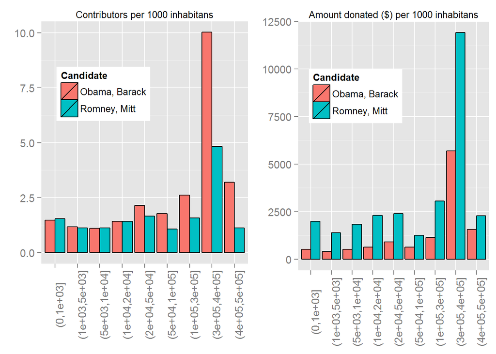

Wow! In towns up to 20k inhabitants (they account for 43% of the total state population) the number of contributors is the same for the two top candidates. It is in towns above 20k people where Obama get donations from more people than Romney do. However, no matter high or small is the population, contributors to the Romney’s fund are a lot more generous.

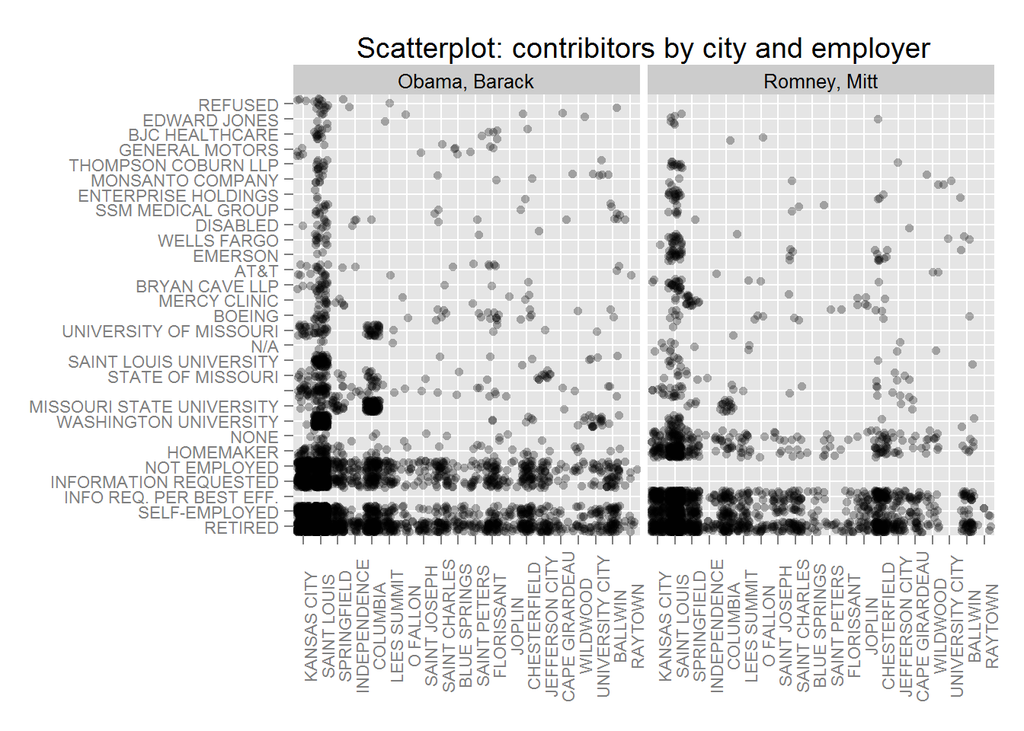

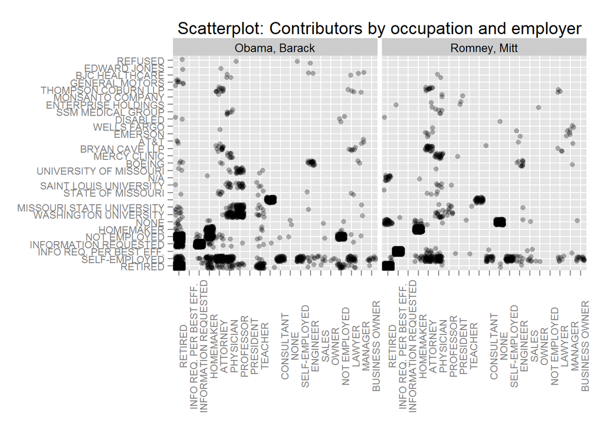

# Multivariate Analysis

### Talk about some of the relationships you observed in this part of the investigation. Were there features that strengthened each other in terms of looking at your feature(s) of interest?

1. For towns with up to 20k population, the number of contributors per 1000 inhabitants is the same for Obama and Romney. Obama got more contributors that Romney in larger cities and especially outperformed Romney in the two largest cities Kansas City and Saint Louis. Obama got much support from universities.

I think that high number of Obama’s contributors in the two largest cities can be an important explanation of his victory in those cities (given the fact he lost the elections in the other Missouri counties *https://en.wikipedia.org/wiki/United_States_presidential_election_in_Missouri,_2012*). This is because people who donated not-very-large amounts of money are more likely to be actively involved in the campaign as volunteers or convince their friends and neighbors to vote for their candidate.

2. Romney got much higher average donation per contributor across all city population groups.
3. High amount of contributions in Joplin, Chesterfield, Jefferson City and some other cities (if compared with cities with similar population) is due to much higher donations to Romney’s fund.

### Were there any interesting or surprising interactions between features?

The employees of the State of Missouri gave more support Obama. This is quite interesting given the fact that Romney won the election in Missouri.

If the information about occupation and employer was not provided, the Romney’s staff reported it as “Information requested per best efforts” while the Obama’s staff reported similar transactions as “Information requested”.

General Motors is represented by retired workers who support Obama.

### OPTIONAL: Did you create any models with your dataset? Discuss the strengths and limitations of your model.

No. I believe the variables in the dataset predict too little information about the campaign result. The results also strongly depend on candidates’ programs or the current issues on the nation’s agenda, but such information is not captured in the dataset. So, there is no point of constructing a model of little predictive power. The dataset is better to be used for revealing the trends and assessing the campaign performance.

# Final Plots and Summary

### Plot One

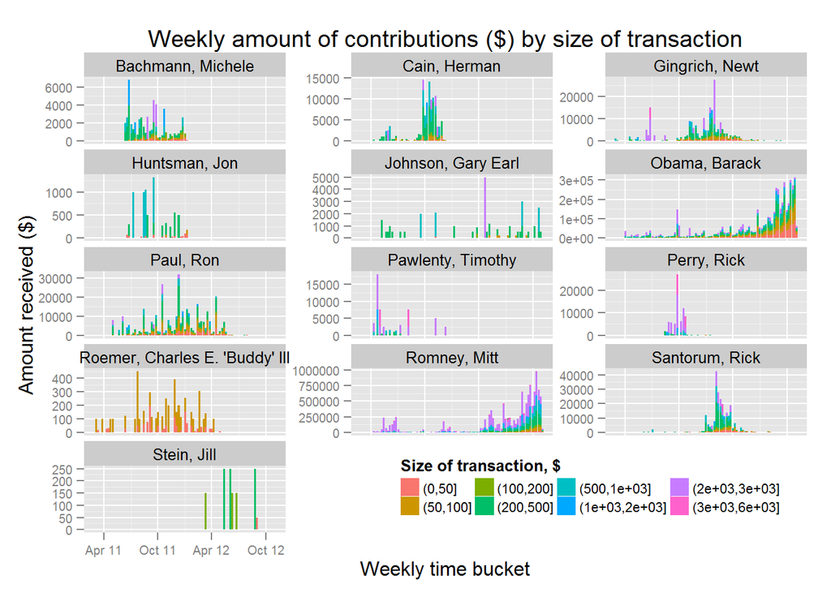

### Description One

This plot is a good start for understanding the funding strategies of all the candidates over the campaign period. We can see the leaders by amount received and have a good guess of where the contributions to their funds came from.

For example, Obama and Romney are the top candidates. They got more money in the latest months prior the Election Date. Obama received much smaller amounts per transaction than Romney did.

### Plot Two

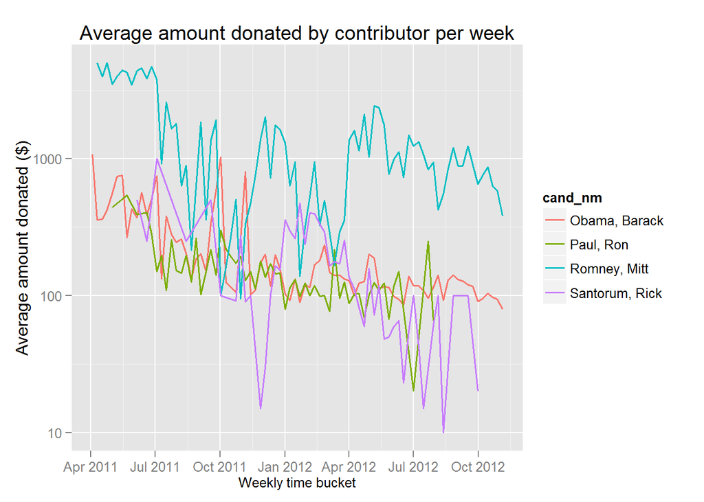

### Description Two

One may assume that Romney’s success in attracting hefty donations is due to the fact that he is from the Republican Party. However, the graph shows that this is not the case.

Only Romney received hefty contributions during the whole campaign period. The average weekly donation to the funds of other major Republican candidates was similar to Obama’s numbers, not Romney’s numbers. The average weekly donation during high campaign season to the Romney’s fund could be 10 times higher than to the funds of the other major candidates.

### Plot Three

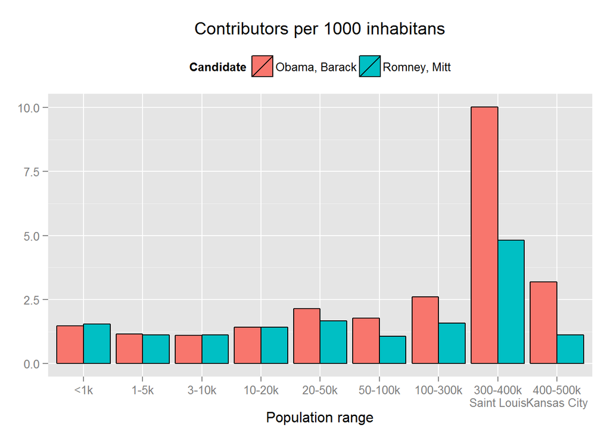

### Description Three

The number of contributors is the same for Obama and Romney in towns up to 20k people. In larger cities, Obama recruits slightly more donators than Romney. Moreover, Obama drastically outperforms Romney in the two largest cities.

# Reflection

The dataset I analyzed have a few problems:

1. There are a number of errors. I had to clean entries with erroneous zip codes or transactions of zero amount. In addition, I had to do an intensive cleaning of city and employer variables in order to obtain the results I can trust.
2. Transactions after the Election Date are not likely to be representative, so I had to exclude them, too.
3. Many refunds or retransfers (negative amount transactions) cannot be matched with their original transactions. I had to exclude such transaction when analyzing time series.
4. The dataset for Missouri is special because Republican primaries were held in this state in 2012. So, there are a number of different Republican candidates to analyze.

It was easy to find the major candidates: Barack Obama (became the President, but lost the election in Missouri) and Mitt Romney (won throughout Missouri, except the two largest cities). It was evident from the beginning that they pursued very different fundraising strategies: Obama got many and small donations while Romney relied on large donations. However, the whole picture was not clear to me at the beginning.

Fortunately, I managed to get two results I proud of. The first (final plot two) explains that Romney’s campaign is strikingly different even from campaigns of the other major Republican candidates, as well as Obama’s campaigns. The average weekly contribution to Romney’s fund could be up to 10 (!) times higher than to the other’s funds. This is a very substantial difference given the high number of contributors (i.e. the results are far from random).

The second (final plot three) shed light on where Obama’s donators come from. They are from larger cities, especially the two largest cities Kansas City and Saint Louis. In terms of number of contributors, Obama did no better than Romney in towns with up to 20k inhabitants (these towns account for 43% of the total state population).

I think that a better conversion rate into donators is one of the key requirements for an election campaign to succeed. So, the next step of research could be to estimate to what extent Obama’s fundraising campaign (i.e. focus on more donators and smaller transactions) helped him to win in the two largest cities in Missouri and possibly obtain higher results in other cities.

One question remains unexplained to me: How Romney managed to get hefty contributions across different cities, employers and occupations. I will research this topic in the future. I think this is not about data analysis. The key is very likely to be in the campaign architecture.